# Ejercicios tema 3

Isaac Subirana

Disseny. Curso: 17-18

# Cuestiones

5. En la siguiente tabla se encuentran los coeficientes mostrados por un colega para un conjunto de contrastes entre medias de tratamiento. Él le pide que los verifique.

| *Tratamiento* | A | B | C | D | E |
| --- | --- | --- | --- | --- | --- |
| C1 | 1 | 3 | -1 | -1 | -1 |
| C2 | 1 | -1 | 0 | -1 | 1 |
| C3 | -1 | 1 | -1 | 1 | -1 |
| C4 | 0 | 0 | 2 | -1 | -1 |

1. ¿Constituye un contraste cada conjunto de coeficientes propuesto? Justifique su respuesta.

Se definen los contrastes y se almacena cada uno en un vector con sus coeficientes

```r
C1 <- c(1,3,-1,-1,-1)
C2 <- c(1,-1,0,-1,1)
C3 <- c(-1,1,-1,1,-1)
C4 <- c(0,0,2,-1,-1)
```

Se colocan por columnas en una matriz (de contrastes) $M_c$.

```r
Mc <- cbind(C1,C2,C3,C4)
Mc
```

```
     C1 C2 C3 C4
[1,]  1  1 -1  0
[2,]  3 -1  1  0
[3,] -1  0 -1  2
[4,] -1 -1  1 -1
[5,] -1  1 -1 -1
```

Primero se comprueba que son contrastes lineales, (si la suma es cero)

```r
colSums(Mc)==0
```

```
   C1    C2    C3    C4
FALSE  TRUE FALSE  TRUE
```

Los contrastes C1 y C3 **no** son contrastes lineales porque sus coeficientes no suman cero.

2. ¿Son ortogonales C1 y C2? Justifique su respuesta.

Miramos si los contrastes lineales son ortogonales. O sea si C2 y C4 son ortogonales.

```r
sum(C2*C4)
```

```
[1] 0
```

Sí lo son.

3. Construya un contraste ortogonal para C4, diferente de lo que se muestra.

Podría ser (-2, -1, 1, 1, 1). Comprovémoslo:

```r
C5 <- c(-2,-1,1,1,1)
sum(C5) # es contraste lineal? (Sí)
```

```
[1] 0
```

```r
sum(C4*C5) # es ortogonal con C4 (sí)
```

```
[1] 0
```

# Exercicios

## Ejercicio 1.

Un fisiólogo de animales estudió la función pituitaria de las gallinas, bajo el régimen estándar de muda de pluma forzada que usan los productores de huevo para mantenerlas en producción. Se usaron 25 gallinas en el estudio. Cinco se utilizaron para la medición, una previa al régimen de muda forzada y una al final de cada una de las cuatro etapas del régimen. Las cinco etapas del régimen fueron: 1) premuda (control), 2) ayuno de 8 días, 3) 60 gramos de salvado al día durante 10 días, 4) 80 gramos de salvado al día por 10 días y 5) mezcla de malta durante 42 días. El objetivo era dar seguimiento a las respuestas fisiológicas asociadas con la función pituitaria de las gallinas durante el régimen para explicar por qué vuelven a producir después de una muda forzada. Uno de los compuestos medidos fue la concentración de suero T3. Los datos de la tabla son las medidas de suero T3 en las cinco gallinas sacrificadas al final de cada etapa del régimen.

| *Tratamiento* |  |  |  |  |  |
| --- | --- | --- | --- | --- | --- |
| Premuda | 94.09, | 90.45, | 99.38, | 73.56, | 74.39 |
| Ayuno | 98.81, | 103.55, | 115.23, | 129.06, | 117.61 |
| 60 g de salvado | 197.18, | 207.31, | 177.50, | 226.05, | 222.74 |
| 80 g de salvado | 102.93, | 117.51, | 119.92, | 112.01, | 101.10 |
| Mezcla de malta | 83.14, | 89.59, | 87.76, | 96.43, | 82.94 |

- Escriba el modelo lineal estadístico para este estudio y explique las componentes del modelo.

Se trata de un diseño de un factor de efectos fijos, (factor es el tratamiento).

$y_{ij} = \mu + \alpha_i + e_{ij}$

$i=1,...,5$ (grupos)

$j=1,...,5$ (réplicas)

$\sum_{i=1}^5 \alpha_i = 0$

$e_{ij} \sim N(0, \sigma^2)$ indep.

- Pruebe la hipótesis de que no hay diferencia entre las medias de los cinco tratamientos con la prueba F a un nivel de significancia de .05.

Entrada de datos

```r
y <- c( 94.09,  90.45,  99.38,  73.56,  74.39,
        98.81, 103.55, 115.23, 129.06, 117.61,
       197.18, 207.31, 177.50, 226.05, 222.74,
       102.93, 117.51, 119.92, 112.01, 101.10,
        83.14,  89.59,  87.76,  96.43,  82.94)

grup <- rep(1:5, each=5)

grup <- factor(grup, labels=c("Premuda","Ayuno","60 g de salvado","80 g de salvado","Mezcla de malta"))
```

Ajuste del modelo

```r
model <- aov(y ~ grup)
```

Tabla **ANOVA**

```r
summary(model)
```

```
            Df Sum Sq Mean Sq F value   Pr(>F)
grup         4  48569   12142   78.08 6.48e-12 ***
Residuals   20   3110     156
---
Signif. codes:  0 '***' 0.001 '**' 0.01 '*' 0.05 '.' 0.1 ' ' 1
```

Sí hay diferencias entre tratamientos.

## Ejercicio 2

Utilizando los datos sobre las concentraciones de suero T3 en los experimentos con gallinas del ejercicio anterior. Las comparaciones de interés eran las diferencias de concentración de suero T3 en las etapas sucesivas: 1) premuda contra ayuno, 2) ayuno contra 60 g de salvado, 3) 60 contra 80 g de salvado y 4) 80 g de salvado contra mezcla de malta:

- Estime cada contraste y su error estándar.

Defineixo els 4 contrastos

```r
C1 <- c(1,-1,0,0,0)  # Premuda vs ayuno
C2 <- c(0,1,-1,0,0)  # Ayuno vs 60g
C3 <- c(0,0,1,-1,0)  # 60 vs 80g
C4 <- c(0,0,0,1,-1)  # 80 g vs mezcla
```

Comprovación que son contrastes lineales y ortogonales

```r
Mc <- cbind(C1,C2,C3,C4)
colSums(Mc) # comprovación contraste lineal
```

```
C1 C2 C3 C4
 0  0  0  0
```

```r
t(Mc)%*%Mc
```

```
   C1 C2 C3 C4
C1  2 -1  0  0
C2 -1  2 -1  0
C3  0 -1  2 -1
C4  0  0 -1  2
```

- Pruebe la hipótesis nula para cada contraste.

Para resolver la hipòtesis de cada constraste, nos guardamos las medias y el MSE obtenido a partir de los datos y la tabla ANOVA del ejercicio anterior. También nos guardamos los grados de libertad del error (`dferror`) para calcular el valor crítico de la F.

```r
medias <- tapply(y, grup, mean)
MSE <- summary(model)[[1]]["Residuals","Mean Sq"]
dferror <- summary(model)[[1]]["Residuals","Df"]
```

Para el contraste 1.

```r
coefs <- C1 # coeficientes del contraste
L <- sum(coefs*medias) # estimación del contraste lineal
n <- 5 # número de réplicas
SS <- n*L^2/sum(coefs^2)
Ftest <- (SS/1)/MSE
Fcrit <- qf(1-0.05,1,dferror)
c("L"=L, "Ftest"=Ftest, "Fcrit"=Fcrit)
```

```
         L      Ftest      Fcrit
-26.478000  11.270769   4.351244
```

Y se puede hacer en un bucle para todos los contrastes

```r
result <- sapply(1:4, function(i){
  coefs <- Mc[,i] # coeficientes del contraste
  L <- sum(coefs*medias) # estimación del contraste lineal
  n <- 5 # número de réplicas
  SS <- n*L^2/sum(coefs^2)
  Ftest <- (SS/1)/MSE  # test F
  Fcrit <- qf(1-0.05,1,dferror) # F crítica
  pvalor <- 1-pf(Ftest, 1, dferror)
  c("L"=L, "SS"=SS, "Ftest"=Ftest, "Fcrit"=Fcrit, "p-valor"=pvalor)
})
result <- t(result)
rownames(result) <- paste0("C",1:4)
result
```

```
         L        SS      Ftest    Fcrit      p-valor
C1 -26.478  1752.711  11.270769 4.351244 3.135828e-03
C2 -93.304 21764.091 139.953490 4.351244 1.748177e-10
C3  95.462 22782.484 146.502240 4.351244 1.167421e-10
C4  22.722  1290.723   8.299966 4.351244 9.237985e-03
```

También se puede hacer mediante la función `fit.contrast` del *package* gmodels:

```r
library(gmodels)
fit.contrast(model,"grup",coeff=C1)
```

```
                      Estimate Std. Error   t value    Pr(>|t|)
grup c=( 1 -1 0 0 0 )  -26.478   7.886937 -3.357197 0.003135828
```

O se puede hacer para todos los contrastes a la vez pasando la matriz de contrastes en el argumento `coeff`:

```r
library(gmodels)
fit.contrast(model,"grup",coeff=t(Mc))
```

```
       Estimate Std. Error    t value     Pr(>|t|)
grupC1  -26.478   7.886937  -3.357197 3.135828e-03
grupC2  -93.304   7.886937 -11.830194 1.748178e-10
grupC3   95.462   7.886937  12.103811 1.167421e-10
grupC4   22.722   7.886937   2.880966 9.237985e-03
```

Fíajate que

- la columna `Estimate` coincide con la estimación del contraste lineal
- el valor de `t value` es la raíz cuadrada (sin tener en cuenta al signo) del valor `Ftest` antes calculado (el signo coincide con el signo de la estimación del constraste lineal).
- el valor de `Std. Error` para el contraste lineal $j$ es
  $$\sqrt{Var\left(\sum_{i=1}^5 c_{ij}\bar{y}_{i·}\right)} =
  \sqrt{\sum_{i=1}^5 c_{ij}^2 Var(\bar{y}_{i·})} =
  \sqrt{\sum_{i=1}^5 c_{ij}^2 \frac{\hat{\sigma}^2}{n}}=
  \sqrt{\sum_{i=1}^5 c_{ij}^2 \frac{MSE}{n}}=
  \sqrt{\frac{MSE}{n}\sum_{i=1}^5 c_{ij}^2}$$

Por lo tanto se puede ver como el valor de Fest coincide con `Fest = L^2 / Std. Error ^2`

- Pregunta adicional: Coincide la suma de cuadrados de los 4 contrastes con la suma de cuadrados entre tratamientos de la tabla ANOVA?

```r
sum(result[,'SS'])
```

```
[1] 47590.01
```

```r
summary(model)
```

```
            Df Sum Sq Mean Sq F value   Pr(>F)
grup         4  48569   12142   78.08 6.48e-12 ***
Residuals   20   3110     156
---
Signif. codes:  0 '***' 0.001 '**' 0.01 '*' 0.05 '.' 0.1 ' ' 1
```

La suma de cuadrados de los contrastes es 47590.01, mientras que la suma de cuadrados entre grupos es 48568.88. Así vemos que no coincide. La teoría nos dice que como los 4 contrastes no son ortogonales las sumas de cuadrados no tienen porqué coincidir.

## Ejercicio 3

Usando los datos del suero T3:

- Realice todas las comparaciones por pares, con el método de Tukey a un nivel de significación de .05.

Con la función `TukeyHSD`

```r
TukeyHSD(model, "grup")
```

```
  Tukey multiple comparisons of means
    95% family-wise confidence level

Fit: aov(formula = y ~ grup)

$grup
                                    diff         lwr        upr     p adj
Ayuno-Premuda                     26.478    2.877329  50.078671 0.0232343
60 g de salvado-Premuda          119.782   96.181329 143.382671 0.0000000
80 g de salvado-Premuda           24.320    0.719329  47.920671 0.0414321
Mezcla de malta-Premuda            1.598  -22.002671  25.198671 0.9995895
60 g de salvado-Ayuno             93.304   69.703329 116.904671 0.0000000
80 g de salvado-Ayuno             -2.158  -25.758671  21.442671 0.9986602
Mezcla de malta-Ayuno            -24.880  -48.480671  -1.279329 0.0357276
80 g de salvado-60 g de salvado  -95.462 -119.062671 -71.861329 0.0000000
Mezcla de malta-60 g de salvado -118.184 -141.784671 -94.583329 0.0000000
Mezcla de malta-80 g de salvado  -22.722  -46.322671   0.878671 0.0626613
```

Esta función da como resultado las comparaciones dos a dos, las diferencias, su intervalo de confianza y el p-valor. Estos dos últimos ya están corregidos por comparaciones múltiples, así que si el p-valor es inferior a $\alpha$ diremos que hay diferencias significativas entre los dos grupos comparados, o equivalentemente, si el intervalo de confianza no contiene el cero diremos también que hay diferencias significativas.

Si queremos visualizar los subgrupos homogéneos

```r
library(agricolae)
HSD.test(model, "grup", console=TRUE)
```

```
Study: model ~ "grup"

HSD Test for y

Mean Square Error:  155.5095

grup,  means

                      y       std r    Min    Max
60 g de salvado 206.156 19.835996 5 177.50 226.05
80 g de salvado 110.694  8.450345 5 101.10 119.92
Ayuno           112.852 11.986426 5  98.81 129.06
Mezcla de malta  87.972  5.542334 5  82.94  96.43
Premuda          86.374 11.759266 5  73.56  99.38

Alpha: 0.05 ; DF Error: 20
Critical Value of Studentized Range: 4.231857

Minimun Significant Difference: 23.60067

Treatments with the same letter are not significantly different.

                      y groups
60 g de salvado 206.156      a
Ayuno           112.852      b
80 g de salvado 110.694     bc
Mezcla de malta  87.972     cd
Premuda          86.374      d
```

- Realice todas las comparaciones por pares, con el método de la diferencia significativa mínima a un nivel de significación de .05.

Usaremos la función `LSD.test` también del *package* `agricolae`

```r
LSD.test(model, "grup", console=TRUE)
```

```
Study: model ~ "grup"

LSD t Test for y

Mean Square Error:  155.5095

grup,  means and individual ( 95 %) CI

                      y       std r       LCL       UCL    Min    Max
60 g de salvado 206.156 19.835996 5 194.52278 217.78922 177.50 226.05
80 g de salvado 110.694  8.450345 5  99.06078 122.32722 101.10 119.92
Ayuno           112.852 11.986426 5 101.21878 124.48522  98.81 129.06
Mezcla de malta  87.972  5.542334 5  76.33878  99.60522  82.94  96.43
Premuda          86.374 11.759266 5  74.74078  98.00722  73.56  99.38

Alpha: 0.05 ; DF Error: 20
Critical Value of t: 2.085963

least Significant Difference: 16.45186

Treatments with the same letter are not significantly different.

                      y groups
60 g de salvado 206.156      a
Ayuno           112.852      b
80 g de salvado 110.694      b
Mezcla de malta  87.972      c
Premuda          86.374      c
```

- Realice todas las comparaciones por pares, con la prueba de Bonferroni a un nivel de significación de .05.

```r
pairwise.t.test(y, grup, p.adjust.method="bonferroni")
```

```
    Pairwise comparisons using t tests with pooled SD

data:  y and grup

                Premuda Ayuno   60 g de salvado 80 g de salvado
Ayuno           0.031   -       -               -
60 g de salvado 1.9e-11 1.7e-09 -               -
80 g de salvado 0.059   1.000   1.2e-09         -
Mezcla de malta 1.000   0.050   2.5e-11         0.092

P value adjustment method: bonferroni
```

Si construímos los subgrupos homogéneos (“con un poco de paciencia”), quedan como

| Régimen | Subgrupo homogéneo |
| --- | --- |
| 60 g de salvado | a |
| Ayuno | b |
| 80 g de salvado | bc |
| Mezcla de salvado | bc |
| Premuda | c |

- ¿En qué difieren los resultados de las tres pruebas?

- Explique por qué difieren los resultados.

Una manera de aumentar la potencia del método de Tukey, por ejemplo, es aumentar la probabilidad del error de tipo I, o sea, $\alpha$:

```r
HSD.test(model, "grup", console=TRUE, alpha=0.1)
```

```
Study: model ~ "grup"

HSD Test for y

Mean Square Error:  155.5095

grup,  means

                      y       std r    Min    Max
60 g de salvado 206.156 19.835996 5 177.50 226.05
80 g de salvado 110.694  8.450345 5 101.10 119.92
Ayuno           112.852 11.986426 5  98.81 129.06
Mezcla de malta  87.972  5.542334 5  82.94  96.43
Premuda          86.374 11.759266 5  73.56  99.38

Alpha: 0.1 ; DF Error: 20
Critical Value of Studentized Range: 3.736403

Minimun Significant Difference: 20.83757

Treatments with the same letter are not significantly different.

                      y groups
60 g de salvado 206.156      a
Ayuno           112.852      b
80 g de salvado 110.694      b
Mezcla de malta  87.972      c
Premuda          86.374      c
```

Ahora, los subgrupos homogéneos creados con el método de Tukey con un nivel de significaciónd el 10% son los mismos obtenidos con un método más potente como LSD a un nivel de significación inferior, del 5%.

- Programa el código para crear una matriz con las diferencias y distinga si éstas son significativas a un nivel $\alpha$ con el método LSD. Compara los resultados con los obtenidos con `LSD.test`.

```r
medias <- tapply(y, grup, mean)
MSE <- summary(model)[[1]]["Residuals","Mean Sq"]
dferror <- summary(model)[[1]]["Residuals","Df"]
k <- length(medias) # número de grupos
r <- 5 # número de réplicas

alpha <- 0.05

vq <- qt(1-alpha/2, dferror)
frontera <- vq*sqrt(MSE*(1/r+1/r))
tabla <- matrix(NA, k, k)
for (i in 1:k){
  for (j in 1:k){
    difer <- medias[i]-medias[j]
    simbolo <- ifelse(abs(difer)>frontera,"*","")
    tabla[i,j] <- paste0(round(abs(difer),2), simbolo)
  }
}

rownames(tabla) <- colnames(tabla) <- levels(grup)

library(knitr)  # para crear tablas en formato Markdown
kable(tabla)
```

|  | Premuda | Ayuno | 60 g de salvado | 80 g de salvado | Mezcla de malta |
| --- | --- | --- | --- | --- | --- |
| Premuda | 0 | 26.48* | 119.78* | 24.32* | 1.6 |
| Ayuno | 26.48* | 0 | 93.3* | 2.16 | 24.88* |
| 60 g de salvado | 119.78* | 93.3* | 0 | 95.46* | 118.18* |
| 80 g de salvado | 24.32* | 2.16 | 95.46* | 0 | 22.72* |
| Mezcla de malta | 1.6 | 24.88* | 118.18* | 22.72* | 0 |

Comparación con los resultados que da la función `HSD.test`. Fíjate con la opción `group=FALSE` para que de las comapraciones dos a dos en lugar de los subgrupos homogéneos

```r
HSD.test(model, "grup", console=TRUE, group=FALSE)
```

```
Study: model ~ "grup"

HSD Test for y

Mean Square Error:  155.5095

grup,  means

                      y       std r    Min    Max
60 g de salvado 206.156 19.835996 5 177.50 226.05
80 g de salvado 110.694  8.450345 5 101.10 119.92
Ayuno           112.852 11.986426 5  98.81 129.06
Mezcla de malta  87.972  5.542334 5  82.94  96.43
Premuda          86.374 11.759266 5  73.56  99.38

Alpha: 0.05 ; DF Error: 20
Critical Value of Studentized Range: 4.231857

Comparison between treatments means

                                  difference pvalue signif.        LCL
60 g de salvado - 80 g de salvado     95.462 0.0000     ***  71.861329
60 g de salvado - Ayuno               93.304 0.0000     ***  69.703329
60 g de salvado - Mezcla de malta    118.184 0.0000     ***  94.583329
60 g de salvado - Premuda            119.782 0.0000     ***  96.181329
80 g de salvado - Ayuno               -2.158 0.9987         -25.758671
80 g de salvado - Mezcla de malta     22.722 0.0627       .  -0.878671
80 g de salvado - Premuda             24.320 0.0414       *   0.719329
Ayuno - Mezcla de malta               24.880 0.0357       *   1.279329
Ayuno - Premuda                       26.478 0.0232       *   2.877329
Mezcla de malta - Premuda              1.598 0.9996         -22.002671
                                        UCL
60 g de salvado - 80 g de salvado 119.06267
60 g de salvado - Ayuno           116.90467
60 g de salvado - Mezcla de malta 141.78467
60 g de salvado - Premuda         143.38267
80 g de salvado - Ayuno            21.44267
80 g de salvado - Mezcla de malta  46.32267
80 g de salvado - Premuda          47.92067
Ayuno - Mezcla de malta            48.48067
Ayuno - Premuda                    50.07867
Mezcla de malta - Premuda          25.19867
```

## Ejercicio 4

Se llevó a cabo un experimento para probar los efectos de un fertilizante nitrogenado en la producción de lechuga. Se aplicaron cinco dosis diferentes de nitrato de amonio a cuatro parcelas (réplicas) en un diseño totalmente aleatorizado. Los datos son el número de lechugas cosechadas de la parcela.

| *Tratamiento (lb N/acre)* | *Lechugas/parcela* |
| --- | --- |
| 0 | 104, 114, 90, 140 |
| 50 | 134, 130, 144, 174 |
| 100 | 146, 142, 152, 156 |
| 150 | 147, 160, 160, 163 |
| 200 | 131, 148, 154, 163 |

- Escriba el modelo lineal estadístico para este estudio y explique sus componentes.

$y_{ij} = \mu + \alpha_i + e_{ij}$

$i=1,\ldots,5$ dosis

$j=1,\ldots,4$ réplicas

$\sum_{i=1}^5 \alpha_i = 0$ Restricción.

- Establezca las suposiciones necesarias para un análisis de varianza de los datos.

$e_{ij} \sim N(0,\sigma)$ independientes

- Calcule el análisis de varianza.

```r
y <- c(104, 114, 90, 140,
       134, 130, 144, 174,
       146, 142, 152, 156,
       147, 160, 160, 163,
       131, 148, 154, 163)

dosis <- factor(rep(1:5, each=4))
dosis <- factor(dosis, labels = seq(0, 200, 50))

model <- aov(y ~ dosis)

summary(model)
```

```
            Df Sum Sq Mean Sq F value  Pr(>F)
dosis        4   4995  1248.7   5.611 0.00576 **
Residuals   15   3338   222.5
---
Signif. codes:  0 '***' 0.001 '**' 0.01 '*' 0.05 '.' 0.1 ' ' 1
```

Vemos como hay diferencias significativas entre dosis.

- Determine la mejor función polinómica de respuesta que describe la relación entre la cosecha de lechuga y el fertilizante de nitrógeno a un nivel de significación de .05.

Mediante la función fit.contrast del package gmodels, especificando los coeficientes de los distintos contrastes.

```r
library(gmodels)
fit.contrast(model, dosis, coeff=rbind(c(-2,-1,0,1,2),
                                      c(2,-1,-2,-1,2),
                                      c(-1,2,0,-2,1),
                                      c(1,-4,6,-4,1)))
```

```
                         Estimate Std. Error    t value    Pr(>|t|)
dosis c=( -2 -1 0 1 2 )        86   23.58672  3.6461196 0.002388768
dosis c=( 2 -1 -2 -1 2 )      -79   27.90818 -2.8307110 0.012650383
dosis c=( -1 2 0 -2 1 )        13   23.58672  0.5511576 0.589641748
dosis c=( 1 -4 6 -4 1 )       -57   62.40459 -0.9133943 0.375483400
```

Son significativas las componentes lineal y cuadráticas, mientras que las de orden superior (3 y 4) no lo son. Por lo tanto, diremos que la mejor relación entre la dosis y la variable respuesta es una parábola.

Alternativamente, si no queremos especificar los coeficientes, podemos usar el argumento `split` del método `summary`. Pero antes hemos de especificar el factor grupo como `ordered` y rehacer el modelo anova:

```r
dosis.ord <- ordered(dosis)
model.ord <- aov(y ~ dosis.ord)
summary(model.ord, split=list(dosis.ord=c(L=1,Q=2,C=3,"^4"=4)))
```

```
                Df Sum Sq Mean Sq F value  Pr(>F)
dosis.ord        4   4995  1248.7   5.611 0.00576 **
  dosis.ord: L   1   2958  2958.4  13.294 0.00239 **
  dosis.ord: Q   1   1783  1783.1   8.013 0.01265 *
  dosis.ord: C   1     68    67.6   0.304 0.58964
  dosis.ord: ^4  1    186   185.7   0.834 0.37548
Residuals       15   3338   222.5
---
Signif. codes:  0 '***' 0.001 '**' 0.01 '*' 0.05 '.' 0.1 ' ' 1
```

Así podemos ajustar una regresión polinómica de orden 2, o sea, una regresión entre la variable respuesta y la componente dosis i dosis al cuadrado, donde la dosi es tratada de forma continua:

```r
dosis.cont <- rep(seq(0,200,50), each=4)
regresion <- lm(y ~ dosis.cont + I(dosis.cont^2))
```

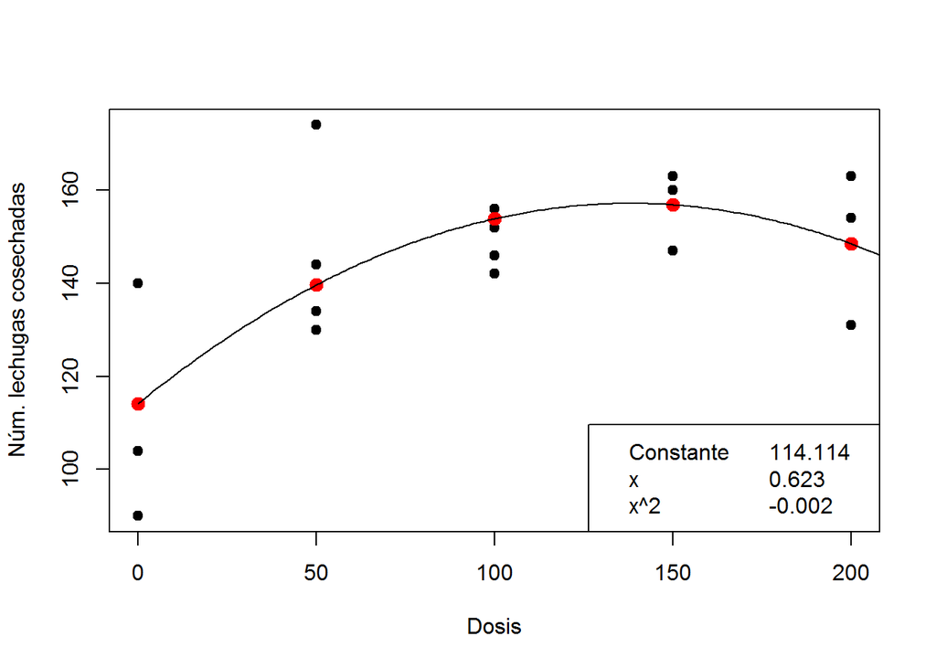

```r
plot(y~dosis.cont, pch=19, xlab="Dosis",ylab="Núm. lechugas cosechadas")
points(dosis.cont, fitted(regresion), col='red', pch=20, cex=2)
lines(0:250,predict(regresion, new=data.frame(dosis.cont=0:250)))
legend("bottomright",c("Constante","x","x^2", round(coef(regresion),3)),ncol=2)
```